# Accidentes - Random Forest

## Tabla accidentes

Preparo la conección con R

```r
#install.packages("RPostgreSQL")
require("RPostgreSQL")
# Guardar el Password para poder posteriormente eliminarlo
pw <- { "1796vd"}

# Leer el driver de PostgreSQL
drv <- dbDriver("PostgreSQL")

# Crear la conexion con la base de datos
con <- dbConnect(drv, dbname = "postgres",
                 host = "localhost", port = 5432,
                 user = "postgres", password = pw)
# Eliminar el Password
rm(pw)

# Chequear que existe la tabla de la base de datos para comprobar la conexión
dbExistsTable(con, "accidente")
```

```
## [1] TRUE
```

Importo los paquetes más genéricos

```r
library(readr)
library(ISLR)
library(ggplot2)
library(caret)
library(dplyr)
library(magrittr)
library(tidyverse)
library(rpart)
library(rpart.plot)
library(hydroTSM)
library(randomForest)
```

Importo la data de la tabla de accidentes

```r
accidente<- dbGetQuery(con, "SELECT * FROM accidente")
head(accidente)
```

```
##   num_expediente id_desc_distrito id_desc_barrio id_desc_dia_semana
## 1    2015S001267               10             72                  5
## 2    2015S000667               10             72                  1
## 3    2015S003072                1              1                  5
## 4    2015S005437               10             67                  3
## 5    2015S003078                2              9                  5
## 6    2015S003069                2             10                  5
##   id_desc_fecha hora id_desc_tipologia  latitud longitud
## 1            49   11                 4 41.42065 2.198739
## 2            26   18                 1 41.41469 2.197742
## 3           128   14                 5 41.37697 2.175581
## 4           195    4                 6 41.39541 2.202903
## 5           128   17                 4 41.38453 2.153185
## 6           128   10                 2 41.37704 2.156269
```

Quiero agrupar por accidentes por distrito. Para ello:

Hago un join para conocer el nombre del distrito y la fecha:

```r
datos <- dbGetQuery(con,
                    "SELECT *
FROM accidente
INNER JOIN descripcion_distrito_accidente ON accidente.id_desc_distrito = descripcion_distrito_accidente.id_desc_distrito
INNER JOIN descripcion_fecha_accidente_y_su_clima ON accidente.id_desc_fecha=descripcion_fecha_accidente_y_su_clima.id_desc_fecha
INNER JOIN descripcion_tipologia_accidente ON accidente.id_desc_tipologia = descripcion_tipologia_accidente.id_desc_tipologia")

head(datos)
```

```
##   num_expediente id_desc_distrito id_desc_barrio id_desc_dia_semana
## 1    2015S001267               10             72                  5
## 2    2015S000667               10             72                  1
## 3    2015S003072                1              1                  5
## 4    2015S005437               10             67                  3
## 5    2015S003078                2              9                  5
## 6    2015S003069                2             10                  5
##   id_desc_fecha hora id_desc_tipologia  latitud longitud id_desc_distrito
## 1            49   11                 4 41.42065 2.198739               10
## 2            26   18                 1 41.41469 2.197742               10
## 3           128   14                 5 41.37697 2.175581                1
## 4           195    4                 6 41.39541 2.202903               10
## 5           128   17                 4 41.38453 2.153185                2
## 6           128   10                 2 41.37704 2.156269                2
##   desc_distrito id_desc_fecha desc_fecha precipitaciones temperatura_max
```

[output cut: 20 more lines]

Selecciono las columnas que voy a utilizar:

```r
datos1<- datos[,c("desc_distrito", "desc_fecha","id_desc_dia_semana", "hora", "desc_tipologia")]
head(datos1)
```

```
##   desc_distrito desc_fecha id_desc_dia_semana hora
## 1    Sant Martí 2015-02-19                  5   11
## 2    Sant Martí 2015-01-27                  1   18
## 3  Ciutat Vella 2015-05-09                  5   14
## 4    Sant Martí 2015-07-15                  3    4
## 5      Eixample 2015-05-09                  5   17
## 6      Eixample 2015-05-09                  5   10
##                    desc_tipologia
## 1                Colisión lateral
## 2         Colisión fronto-lateral
## 3                       Atropello
## 4                         Alcance
## 5                Colisión lateral
## 6 Choque contra elemento estático
```

Para buscar los días de la semana:

```r
dia_sem <-dbGetQuery(con, "SELECT * FROM descripcion_dia_semana_accidente")
dia_sem
```

```
##   id_desc_dia_semana desc_dia_semana
## 1                  1          martes
## 2                  2          sabado
## 3                  3       miercoles
## 4                  4         viernes
## 5                  5          jueves
## 6                  6         domingo
## 7                  7           lunes
```

```r
datos1$id_desc_dia_semana<-ifelse(datos1$id_desc_dia_semana == 1, 7, datos1$id_desc_dia_semana)
datos1$id_desc_dia_semana<-ifelse(datos1$id_desc_dia_semana == 2, 1, datos1$id_desc_dia_semana)
datos1$id_desc_dia_semana<-ifelse(datos1$id_desc_dia_semana == 3, 3, datos1$id_desc_dia_semana)
datos1$id_desc_dia_semana<-ifelse(datos1$id_desc_dia_semana == 4, 5, datos1$id_desc_dia_semana)
datos1$id_desc_dia_semana<-ifelse(datos1$id_desc_dia_semana == 5, 4, datos1$id_desc_dia_semana)
datos1$id_desc_dia_semana<-ifelse(datos1$id_desc_dia_semana == 6, 2, datos1$id_desc_dia_semana)
datos1$id_desc_dia_semana<-ifelse(datos1$id_desc_dia_semana == 7, 6, datos1$id_desc_dia_semana)
```

También determino si es de madrugada, mañana, tarde o noche:

```r
for(i in 1:nrow(datos1))
  {
  if      (datos1$hora[i] < 7.0)  { datos1$horario[i]<-"madrugada"}
  else if (datos1$hora[i] >= 19.0){ datos1$horario[i]<-"noche"}
  else if (datos1$hora[i] >= 13.0){ datos1$horario[i]<-"tarde"}
  else                            { datos1$horario[i]<-"mañana"}
  }

head(datos1)
```

```
##   desc_distrito desc_fecha id_desc_dia_semana hora
## 1    Sant Martí 2015-02-19                  4   11
## 2    Sant Martí 2015-01-27                  6   18
## 3  Ciutat Vella 2015-05-09                  4   14
## 4    Sant Martí 2015-07-15                  3    4
## 5      Eixample 2015-05-09                  4   17
## 6      Eixample 2015-05-09                  4   10
##                    desc_tipologia   horario
## 1                Colisión lateral    mañana
## 2         Colisión fronto-lateral     tarde
## 3                       Atropello     tarde
## 4                         Alcance madrugada
## 5                Colisión lateral     tarde
## 6 Choque contra elemento estático    mañana
```

Ahora agrupo:

```r
datos2<- datos1 %>%
  group_by(desc_distrito, desc_tipologia, horario, id_desc_dia_semana) %>%
  summarise(cant_tipologias_distrito=n())
datos2
```

```
## # A tibble: 1,952 x 5
## # Groups:   desc_distrito, desc_tipologia, horario [485]
##    desc_distrito desc_tipologia horario  id_desc_dia_sem… cant_tipologias_…
##    <chr>         <chr>          <chr>               <dbl>             <int>
##  1 Ciutat Vella  Alcance        madruga…                1                 8
##  2 Ciutat Vella  Alcance        madruga…                2                 7
##  3 Ciutat Vella  Alcance        madruga…                3                 2
##  4 Ciutat Vella  Alcance        madruga…                4                 8
##  5 Ciutat Vella  Alcance        madruga…                6                10
##  6 Ciutat Vella  Alcance        mañana                  1                 5
##  7 Ciutat Vella  Alcance        mañana                  2                 5
##  8 Ciutat Vella  Alcance        mañana                  3                13
##  9 Ciutat Vella  Alcance        mañana                  4                27
## 10 Ciutat Vella  Alcance        mañana                  6                28
## # … with 1,942 more rows
```

“desc_distrito”, “desc_fecha”,“id_desc_dia_semana”, “hora”, “desc_tipologia” Lo que hice fue contar cuantos registros hay en cada distrito según la tipología, el horario y el día de la semana.

Convierto en factor las demás variables:

```r
datos2$id_desc_dia_semana<-as.factor(datos2$id_desc_dia_semana)
datos2$desc_tipologia<-as.factor(datos2$desc_tipologia)
datos2$horario<-as.factor(datos2$horario)
```

Partimos el dataset en 2 grupos para trabajar entrenamiento y validación

```r
set.seed(12)
```

```r
smp_size <- floor(0.75 * nrow(datos2))

set.seed(123)
train_ind <- sample(seq_len(nrow(datos2)), size = smp_size)

train <- datos2[train_ind, ]
test <- datos2[-train_ind, ]
```

Ahora hago el modelo

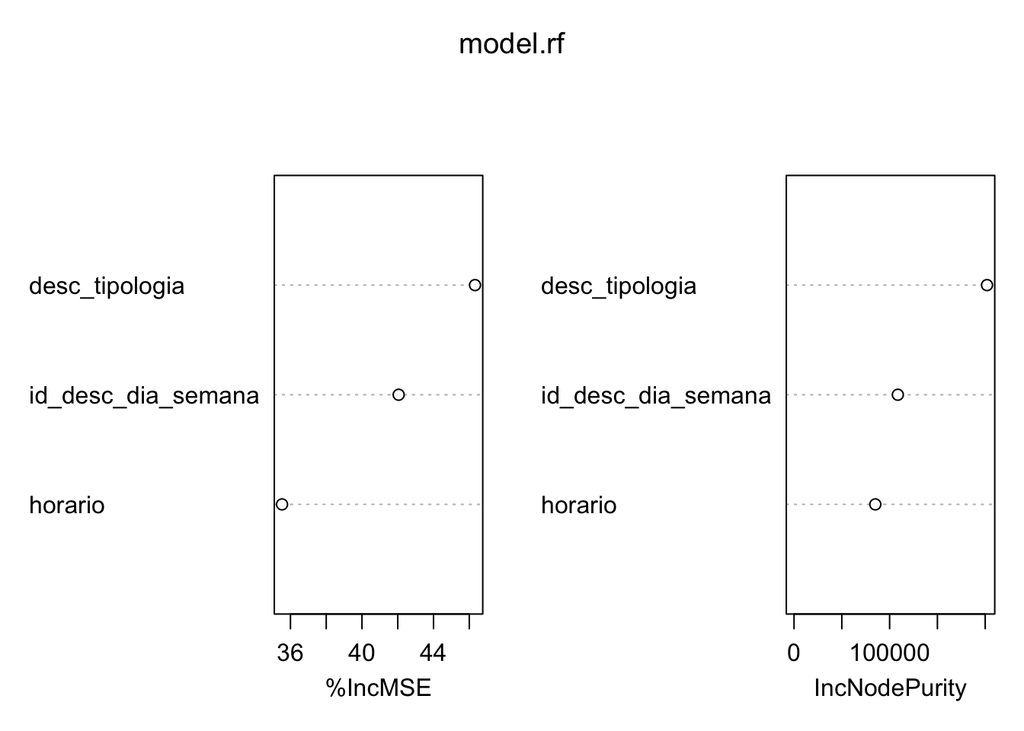

```r
model.rf <- randomForest(formula = cant_tipologias_distrito ~ desc_tipologia + horario + id_desc_dia_semana, importance = TRUE ,data = train)
varImpPlot(model.rf)
```

```r
summary(model.rf)
```

```
##                 Length Class  Mode
## call               4   -none- call
## type               1   -none- character
## predicted       1464   -none- numeric
## mse              500   -none- numeric
## rsq              500   -none- numeric
## oob.times       1464   -none- numeric
## importance         6   -none- numeric
## importanceSD       3   -none- numeric
## localImportance    0   -none- NULL
## proximity          0   -none- NULL
## ntree              1   -none- numeric
## mtry               1   -none- numeric
## forest            11   -none- list
## coefs              0   -none- NULL
## y               1464   -none- numeric
## test               0   -none- NULL
## inbag              0   -none- NULL
## terms              3   terms  call
```

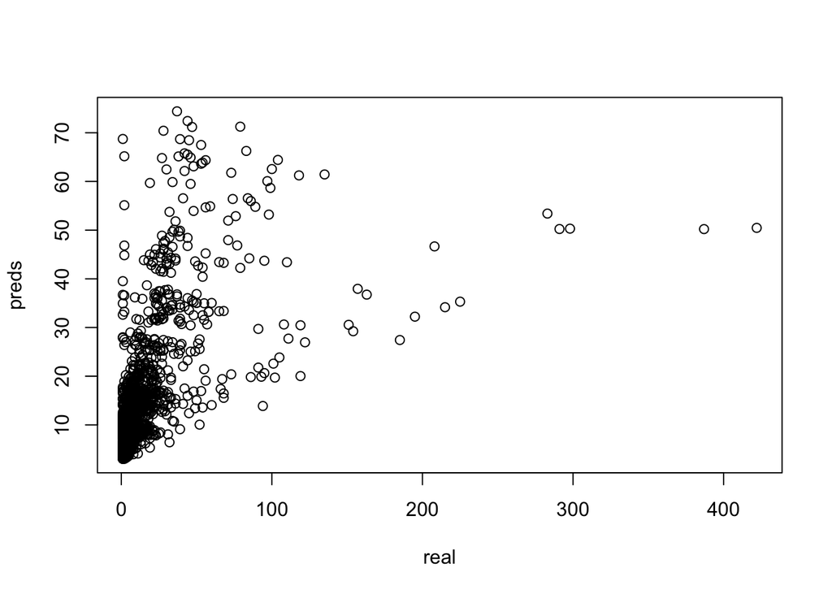

```r
preds <- predict(model.rf,data = train)
real <- train$cant_tipologias_distrito
plot(real, preds)
```

```r
RMSE <- sqrt(mean((real - preds)^2))
RMSE
```

```
## [1] 24.90173
```